# Ford GoBike System Data Exploration

Ford GoBike data set includes information about individual rides made in a bike-sharing system covering the greater San Francisco Bay area. Data contains information about Trips, Stations, Bikes and Users.

```python
# import all packages and set plots to be embedded inline
import numpy as np
import pandas as pd
import matplotlib.pyplot as plt
import seaborn as sb

%matplotlib inline

#select color palette
color_palette = sb.color_palette()[0]
```

```python
# helper methods
from IPython.core.display import display, HTML
from base64 import b64encode
from io import BytesIO
from math import sin, cos, sqrt, atan2, radians
import uuid

#----------------------------------------------------------------------------------------------------------
def new_figId():
    '''
    generate and return new uuid as figure identifier.
    '''
    return str(uuid.uuid4())

#----------------------------------------------------------------------------------------------------------
def visualize(*items, **kwargs):
    '''
    Print pandas DataFrames / figure / seaborn plot / matplotlib plot side-by-side (inline).

            Parameters:
                    *items: items (pd/plot...etc) to be displayed side by side
                    **kwargs: options (title for all, dataframes captions, captions color and size)

    '''
    options = {'title':None, 'df_titles' : [], 'df_titles_color' : 'black', 'df_titles_font_size' : '14px'}
    options.update(kwargs)

    title = options['title'] if options['title'] != None else ''
    table_height, df_count = 'auto', -1
    data = f'<div style="text-align: center;"><span style="text-align: center;font-weight: bold;">{title}</span></div>'

    for item in items:
        #print(item)

        if isinstance(item, str):
            item = f'<span style="color:blue">{item}</span>'
            #table_height = '95%'

        elif isinstance(item, pd.DataFrame):
            df_count += 1
            caption = str(options['df_titles'][df_count]) if(len(options['df_titles'])>df_count) else ''
            item = (item.style.set_table_attributes("style='display:inline;margin-right:20px;'")
                             .set_caption(caption)
                             .set_table_styles([{'selector': 'caption',
                                                 'props': [('color', options['df_titles_color']),
                                                           ('font-size', options['df_titles_font_size'])]}])
                             ._repr_html_() + "\xa0\xa0\xa0")

        elif('AxesSubplot' in str(type(item)) or type(item)==plt.Figure):
            item = item.get_figure() if type(item)!=plt.Figure else item
            figdata = BytesIO()  #plt.tight_layout()
            item.savefig(figdata, format='png', bbox_inches = "tight")
            #item.legends = []
            plt.close()
            item =  f'<img src="data:…)).decode()}"/>'

        elif("seaborn.axisgrid" in str(type(item))):
            item = item.fig #if type(item)!=plt.Figure else item
            figdata = BytesIO()  #plt.tight_layout()
            item.savefig(figdata, format='png', bbox_inches = "tight")
            #item.legends = []
            plt.close()
            item =  f'<img src="data:…)).decode()}"/>'

        data += (f"""<table style="display:inline-block; height:{table_height}">
                        <tr style="background-color: transparent;vertical-align: top;">
                            <td style="background-color: transparent;vertical-align: top;text-align: left;">{item}</td>
                        </tr>
                    </table>""")
    display(HTML(str("<style>div.output_scroll { height: auto;  }</style>")))
    display(HTML(data))

#----------------------------------------------------
def set_countplot_percentage(feature, ax, label_hight_offset = 1):
    '''
    set percentage as annotation over the bars or count plot.

            Parameters:
                    feature: column to be plotted
                    ax: axis plot object
                    label_hight_offset: amount to shift of the percent away from the bar

    '''
    total = len(feature)
    for p in ax.patches:
        percentage = '{:.1f}%'.format(100 * p.get_height()/total)
        x = p.get_x() + p.get_width()/2
        y = p.get_height() + (label_hight_offset * 1000)
        ax.annotate(percentage, (x, y), ha='center')
```

```python
# load in the dataset into a pandas dataframe
df_org = pd.read_csv('201902-fordgobike-tripdata.csv')
df = df_org.copy()
df.head()
```

|  | duration_sec | start_time | end_time | start_station_id | start_station_name | start_station_latitude | start_station_longitude | end_station_id | end_station_name | end_station_latitude | end_station_longitude | bike_id | user_type | member_birth_year | member_gender | bike_share_for_all_trip |
| --- | --- | --- | --- | --- | --- | --- | --- | --- | --- | --- | --- | --- | --- | --- | --- | --- |
| 0 | 52185 | 2019-02-28 17:32:10.1450 | 2019-03-01 08:01:55.9750 | 21.0 | Montgomery St BART Station (Market St at 2nd St) | 37.789625 | -122.400811 | 13.0 | Commercial St at Montgomery St | 37.794231 | -122.402923 | 4902 | Customer | 1984.0 | Male | No |
| 1 | 42521 | 2019-02-28 18:53:21.7890 | 2019-03-01 06:42:03.0560 | 23.0 | The Embarcadero at Steuart St | 37.791464 | -122.391034 | 81.0 | Berry St at 4th St | 37.775880 | -122.393170 | 2535 | Customer | NaN | NaN | No |
| 2 | 61854 | 2019-02-28 12:13:13.2180 | 2019-03-01 05:24:08.1460 | 86.0 | Market St at Dolores St | 37.769305 | -122.426826 | 3.0 | Powell St BART Station (Market St at 4th St) | 37.786375 | -122.404904 | 5905 | Customer | 1972.0 | Male | No |
| 3 | 36490 | 2019-02-28 17:54:26.0100 | 2019-03-01 04:02:36.8420 | 375.0 | Grove St at Masonic Ave | 37.774836 | -122.446546 | 70.0 | Central Ave at Fell St | 37.773311 | -122.444293 | 6638 | Subscriber | 1989.0 | Other | No |
| 4 | 1585 | 2019-02-28 23:54:18.5490 | 2019-03-01 00:20:44.0740 | 7.0 | Frank H Ogawa Plaza | 37.804562 | -122.271738 | 222.0 | 10th Ave at E 15th St | 37.792714 | -122.248780 | 4898 | Subscriber | 1974.0 | Male | Yes |

```python
df.shape
```

```
(183412, 16)
```

```python
df.describe()
```

|  | duration_sec | start_station_id | start_station_latitude | start_station_longitude | end_station_id | end_station_latitude | end_station_longitude | bike_id | member_birth_year |
| --- | --- | --- | --- | --- | --- | --- | --- | --- | --- |
| count | 183412.000000 | 183215.000000 | 183412.000000 | 183412.000000 | 183215.000000 | 183412.000000 | 183412.000000 | 183412.000000 | 175147.000000 |
| mean | 726.078435 | 138.590427 | 37.771223 | -122.352664 | 136.249123 | 37.771427 | -122.352250 | 4472.906375 | 1984.806437 |
| std | 1794.389780 | 111.778864 | 0.099581 | 0.117097 | 111.515131 | 0.099490 | 0.116673 | 1664.383394 | 10.116689 |
| min | 61.000000 | 3.000000 | 37.317298 | -122.453704 | 3.000000 | 37.317298 | -122.453704 | 11.000000 | 1878.000000 |
| 25% | 325.000000 | 47.000000 | 37.770083 | -122.412408 | 44.000000 | 37.770407 | -122.411726 | 3777.000000 | 1980.000000 |
| 50% | 514.000000 | 104.000000 | 37.780760 | -122.398285 | 100.000000 | 37.781010 | -122.398279 | 4958.000000 | 1987.000000 |
| 75% | 796.000000 | 239.000000 | 37.797280 | -122.286533 | 235.000000 | 37.797320 | -122.288045 | 5502.000000 | 1992.000000 |
| max | 85444.000000 | 398.000000 | 37.880222 | -121.874119 | 398.000000 | 37.880222 | -121.874119 | 6645.000000 | 2001.000000 |

```python
df.info()
```

```
<class 'pandas.core.frame.DataFrame'>
RangeIndex: 183412 entries, 0 to 183411
Data columns (total 16 columns):
 #   Column                   Non-Null Count   Dtype
---  ------                   --------------   -----
 0   duration_sec             183412 non-null  int64
 1   start_time               183412 non-null  object
 2   end_time                 183412 non-null  object
 3   start_station_id         183215 non-null  float64
 4   start_station_name       183215 non-null  object
 5   start_station_latitude   183412 non-null  float64
 6   start_station_longitude  183412 non-null  float64
 7   end_station_id           183215 non-null  float64
 8   end_station_name         183215 non-null  object
 9   end_station_latitude     183412 non-null  float64
 10  end_station_longitude    183412 non-null  float64
 11  bike_id                  183412 non-null  int64
 12  user_type                183412 non-null  object
 13  member_birth_year        175147 non-null  float64
 14  member_gender            175147 non-null  object
 15  bike_share_for_all_trip  183412 non-null  object
dtypes: float64(7), int64(2), object(7)
memory usage: 22.4+ MB
```

```python
df.duplicated().sum()
```

```
0
```

## Data Wrangling

For better analysis and insights, member_age will be calculated from the member_birth_year given that the data is for 2019.

```python
df['member_age'] = 2019-df['member_birth_year']
```

Is there any nulls in Age? if yes, drop the trips with null member age

```python
print(f'{df.member_age.isnull().sum()} null member ages to be dropped')
df = df[df.member_age.notnull()]

#convery member_age to int
df.member_age = df.member_age.astype('int')
df.duration_min = df.member_age.astype('float')
```

```
8265 null member ages to be dropped
```

```python
# convert start and end time to datetime format
df.start_time = pd.to_datetime(df.start_time)
df.end_time = pd.to_datetime(df.end_time)

# determine if trip is at day or night time
df['trip_day_night'] = pd.to_datetime(df.start_time, unit='s').apply(lambda x: "Day" if x.hour >= 6 and x.hour <= 18 else "Night")
# determine day name for each trip based on trip start_time
df['trip_day'] = df.start_time.dt.day_name()
# determine trip duration in min from duration in sec
df['duration_min'] = round(df.duration_sec/60,0)
# determine start hour
df['start_hour']= df['start_time'].dt.hour
```

```python
# Convert to categoral.
gender = list(df.member_gender.value_counts().index)
gender = pd.api.types.CategoricalDtype(ordered = True, categories = gender)
df.member_gender = df.member_gender.astype(gender)

day = list(df.trip_day.value_counts().index)
day = ['Monday', 'Tuesday', 'Wednesday', 'Thursday', 'Friday', 'Saturday', 'Sunday']
day = pd.api.types.CategoricalDtype(ordered = True, categories = day)
df.trip_day = df.trip_day.astype(day)
```

```python
#drop non-useful columns after cleaning

df.drop(['start_time', 'end_time','duration_sec','member_birth_year',
         'bike_id', 'start_station_name', 'end_station_name',
         'bike_share_for_all_trip', 'start_station_latitude', 'start_station_longitude',
         'end_station_latitude', 'end_station_longitude'], axis=1, inplace=True, errors='ignore')
df.head()
```

|  | start_station_id | end_station_id | user_type | member_gender | member_age | trip_day_night | trip_day | duration_min | start_hour |
| --- | --- | --- | --- | --- | --- | --- | --- | --- | --- |
| 0 | 21.0 | 13.0 | Customer | Male | 35 | Day | Thursday | 870.0 | 17 |
| 2 | 86.0 | 3.0 | Customer | Male | 47 | Day | Thursday | 1031.0 | 12 |
| 3 | 375.0 | 70.0 | Subscriber | Other | 30 | Day | Thursday | 608.0 | 17 |
| 4 | 7.0 | 222.0 | Subscriber | Male | 45 | Night | Thursday | 26.0 | 23 |
| 5 | 93.0 | 323.0 | Subscriber | Male | 60 | Night | Thursday | 30.0 | 23 |

```python
df.shape
```

```
(175147, 9)
```

### Dataset structure

The original dataset contains 183,412 trip. Features are realated to trip, statation, bike and user as shown below.

- Trip (duration, start & end time)
- Station (start & end station id, name, geographic coordinates)
- Bike id
- User (Customer or subscriber, gender, birth year)

Some feature data types need adjustment like start and end time should be in datetime format, also categoral data like member_gender and user_type would be better to change to categoral type.

## Univariate Exploration

### Exploring the Duration feature

Description of Duration

[output not shown]

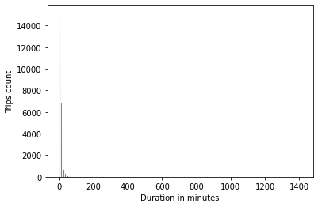

```python
dsc = pd.DataFrame(df.duration_min.describe())

hst = sb.histplot(data = df, x = 'duration_min')
hst.set(xlabel='Duration in minutes', ylabel='Trips count')


visualize(dsc, hst, df_titles=['Description of Duration'], df_titles_color='green')
```

Duration data is skewed to the right with very long-tail. There are some trips with long duration 1400 min (23 hour). Plotting trip durations on a log-scale should result in a better visualzation

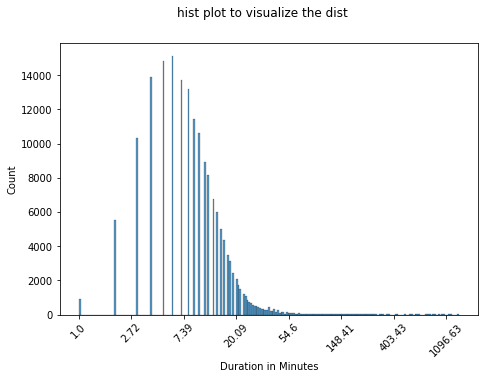

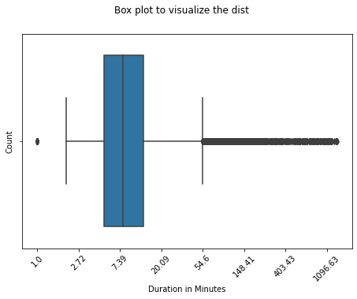

```python
## there's a long tail in the distribution, so let's put it on a log scale instead

# create log_duration_min in the dataframe to use it
df['log_duration_min']= df['duration_min'].apply(np.log)

plt.figure(new_figId(), figsize=(7.5, 5)).suptitle('hist plot to visualize the dist')
hst= sb.histplot(data = df, x = 'log_duration_min');
hst.set_xticklabels([round(np.exp(i),2) for i in plt.xticks()[0]], rotation=45);
hst.set(xlabel='Duration in Minutes', ylabel='Count')

plt.figure(new_figId(), figsize=(7.5, 5)).suptitle('Box plot to visualize the dist')
bx= sb.boxplot(data = df, x = 'log_duration_min');
bx.set_xticklabels([round(np.exp(i),2) for i in plt.xticks()[0]], rotation=45);
bx.set(xlabel='Duration in Minutes', ylabel='Count', xticklabels=[round(np.exp(i),2) for i in plt.xticks()[0]])


visualize(hst, bx);
```

- The average trip duration is approximately 11 min
- The most trips took 5 to 15 min
- There are some trips took from 55 min to more than 18 hours

### Exploring the Age feature

Describtion

|  | member_age |
| --- | --- |
| count | 175147.000000 |
| mean | 34.193563 |
| std | 10.116689 |
| min | 18.000000 |
| 25% | 27.000000 |
| 50% | 32.000000 |
| 75% | 39.000000 |
| max | 141.000000 |

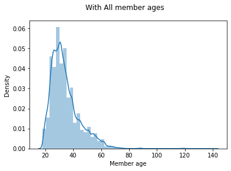

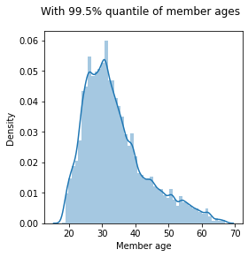

```python
dsc = pd.DataFrame(df.member_age.describe())

# visualize all member ages
dst_100 = plt.figure(new_figId())
dst_100.suptitle('With All member ages')
sb.distplot(df.member_age).set(xlabel='Member age');

# visualize 99.5% quantile of member ages
dst_995 = plt.figure(new_figId(), figsize=(4,4))
dst_995.suptitle('With 99.5% quantile of member ages')
sb.distplot(df[df.member_age < df.member_age.quantile(.995)].member_age).set(xlabel='Member age');

visualize(dsc, dst_100, dst_995, df_titles=['Describtion'])
```

Having members with age upto 140 is impossible, it's an indicator that there are outliers. However, 99.5% of the trips took place by members under 70 which is fair enough for the analysis. Accordingly, trips by member of age > 70 will be droped.

```python
# select trips by member ages < 70 and check if there are any nulls afterwards
df = df[df.member_age < 70]
df.member_age.isnull().sum()
```

```
0
```

Member Age description

|  | member_age |
| --- | --- |
| count | 174473.000000 |
| mean | 34.015332 |
| std | 9.677684 |
| min | 18.000000 |
| 25% | 27.000000 |
| 50% | 32.000000 |
| 75% | 39.000000 |
| max | 69.000000 |

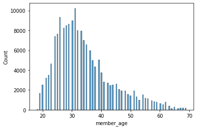

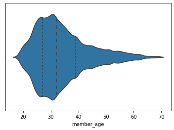

```python
dsc = pd.DataFrame(df.member_age.describe())

hst = plt.figure(new_figId());
sb.histplot(data = df, x= 'member_age')

vln = plt.figure(new_figId());
sb.violinplot(data = df, x= 'member_age', inner='quartile')

visualize(dsc, hst, vln, df_titles=['Member Age description'])
```

### Exploring User Gender and Type

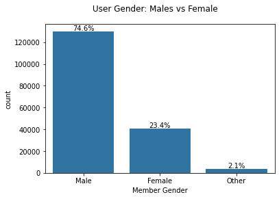

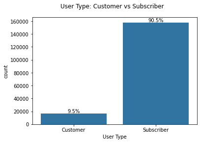

```python
gender_fig = plt.figure(new_figId());
gender_fig.suptitle('User Gender: Males vs Female ')
ax = sb.countplot(data= df, x= 'member_gender', color = color_palette);
ax.set(xlabel='Member Gender')
set_countplot_percentage(df['user_type'], ax)

day_night_fig = plt.figure(new_figId());
day_night_fig.suptitle('User Type: Customer vs Subscriber')
ax = sb.countplot(data= df, x= 'user_type', color = color_palette);
ax.set(xlabel='User Type')
set_countplot_percentage(df['user_type'], ax)

visualize(gender_fig, day_night_fig)
```

- Trips by Males are around 75%, 24% by Females and 2% by Other.
- Trips by Subscriber are around 90% and 10% by Customer.

### Exploring Trip day/night, Trip Day of weeks and Trips start hours

Exploring Trip day/night, Trip Day of weeks and Trips start hours

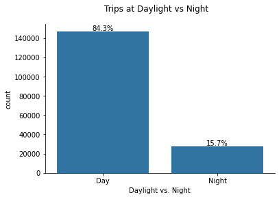

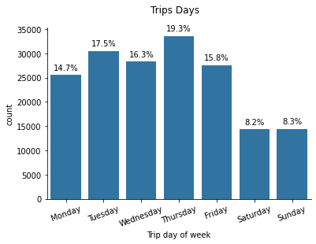

```python
days_fig = plt.figure(new_figId());
days_fig.suptitle('Trips Days')
ax = sb.countplot(data= df, x = 'trip_day', color = color_palette);
ax.set_xticklabels(labels= plt.xticks()[1], rotation=20)
ax.set(xlabel='Trip day of week')
set_countplot_percentage(df.trip_day, ax)
sb.despine(days_fig, ax, top=True)

day_night_fig = plt.figure(new_figId());
day_night_fig.suptitle('Trips at Daylight vs Night')
ax= sb.countplot(data= df, x= 'trip_day_night', color = color_palette);
ax.set(xlabel='Daylight vs. Night')
set_countplot_percentage(df.trip_day_night, ax)
sb.despine(day_night_fig, ax, top=True)

visualize(day_night_fig, days_fig, title='Exploring Trip day/night, Trip Day of weeks and Trips start hours')
```

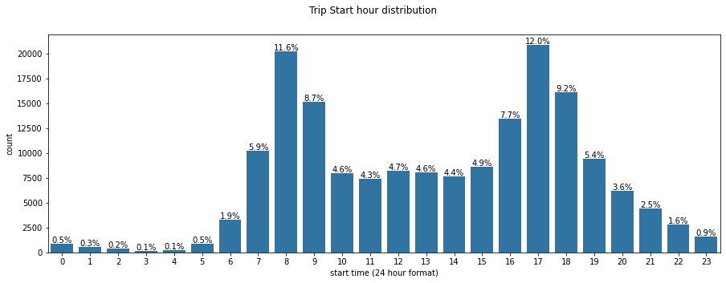

```python
start_hour_fig = plt.figure(new_figId(), figsize=(15,5));
start_hour_fig.suptitle('Trip Start hour distribution')
ax = sb.countplot(data= df, x= 'start_hour', color = color_palette);
ax.set_xlabel('start time (24 hour format)')
set_countplot_percentage(df.start_hour, ax, 0.1)
#sb.despine(start_hour_fig, ax, top=True)

visualize(start_hour_fig)
```

- Trips at Daytime is ~ 84% vs ~ 16% for Night trips.
- Trips from Monday to Friday are nearly similar
- Trips on Sunday and Saturday,are less than other days. This suggest that bikes are being used to commute in working days.
- Trips Star hour are approximately between 7:00 - 9:00 am and 4:00 - 6:00 pm, Which also suggest the commuting to work suggestion.

# Univariate Exploration Summary

**Duration**

- Duration data is skewed to the right with very long-tail. Log transformation is used to get better visualzation
- The average trip duration is approximately 11 min
- The most trips took 5 to 15 min
- There are some trips took from 55 min to more than 18 hours, whch might or might not be outliers.

**User Type & Member Gender**

- Trips by Males are around 75%, 24% by Females and 2% by Other.
- Trips by Subscriber are around 90% and 10% by Customer.

**Timing**

- Trips at Daytime is ~ 84% vs ~ 16% for Night trips.
- Trips from Monday to Friday are nearly similar
- Trips on Sunday and Saturday,are less than other days. This suggest that bikes are being used to commute in working days.
- Trips Star hour are approximately between 7:00 - 9:00 am and 4:00 - 6:00 pm, Which also suggest the commuting to work suggestion.

## Bivariate Exploration

```python
df.head()
```

|  | start_station_id | end_station_id | user_type | member_gender | member_age | trip_day_night | trip_day | duration_min | start_hour | log_duration_min |
| --- | --- | --- | --- | --- | --- | --- | --- | --- | --- | --- |
| 0 | 21.0 | 13.0 | Customer | Male | 35 | Day | Thursday | 870.0 | 17 | 6.768493 |
| 2 | 86.0 | 3.0 | Customer | Male | 47 | Day | Thursday | 1031.0 | 12 | 6.938284 |
| 3 | 375.0 | 70.0 | Subscriber | Other | 30 | Day | Thursday | 608.0 | 17 | 6.410175 |
| 4 | 7.0 | 222.0 | Subscriber | Male | 45 | Night | Thursday | 26.0 | 23 | 3.258097 |
| 5 | 93.0 | 323.0 | Subscriber | Male | 60 | Night | Thursday | 30.0 | 23 | 3.401197 |

```python
#spcify the numeric and the categoral features
numeric_vars = ['member_age', 'duration_min', 'start_hour']
categoric_vars = ['user_type', 'member_gender', 'trip_day_night', 'trip_day']
```

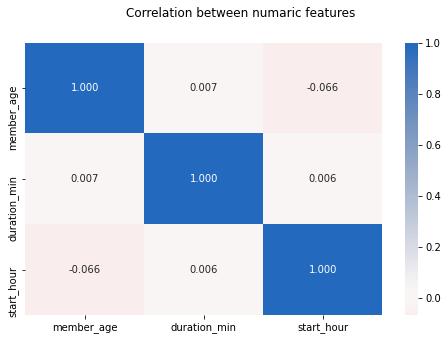

```python
# visualize the correlation between numaric features
plt.figure(new_figId(), figsize=(8,5)).suptitle('Correlation between numaric features')
sb.heatmap(df[numeric_vars].corr(), annot = True, fmt = '.3f', cmap = 'vlag_r', center = 0);
```

There is not strong correlation between age, duration, start hour

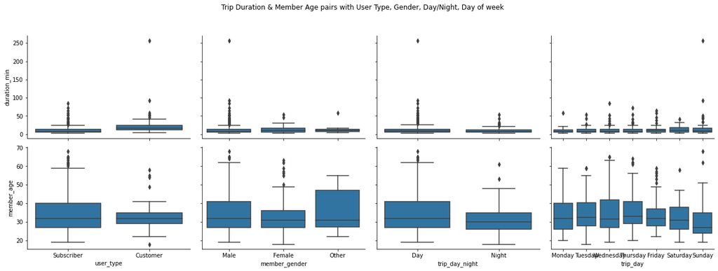

```python
#df.duration_min = df[df.duration_min < 100 ]
#print(df.shape)
df_sample = df.sample(n=500, replace=True, random_state=0)

def boxgrid(x, y, **kwargs):
    default_color = sb.color_palette()[0];
    sb.boxplot(x=x, y=y, color = default_color);

plt.figure(new_figId(), figsize = [15, 15]);
g = sb.PairGrid(data= df_sample, y_vars= ['duration_min', 'member_age'], x_vars= categoric_vars, height= 3, aspect= 1.5);
g.fig.suptitle('Trip Duration & Member Age pairs with User Type, Gender, Day/Night, Day of week', y=1.1);
g.map(boxgrid);
```

The above Duration pair grid may suggest that the duration over 100 min could be outliers. However, it will be assumed not to be outliers and will be kept.

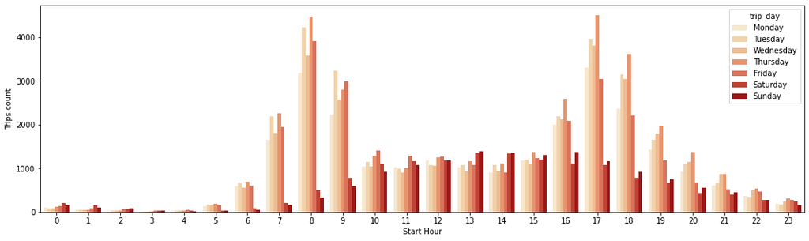

```python
f_sh_td= plt.figure(new_figId(), figsize=(18,5))
sb.countplot(data= df, x= 'start_hour', hue='trip_day', palette= 'OrRd').set(xlabel='Start Hour', ylabel='Trips count');
```

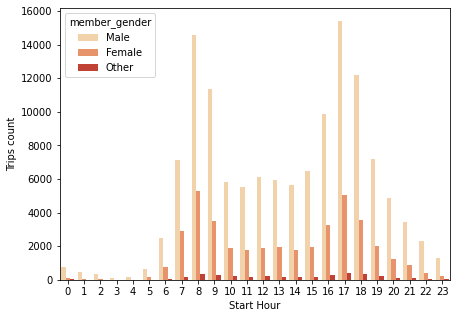

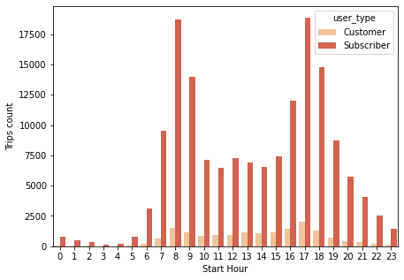

```python
f_sh_mg= plt.figure(new_figId(), figsize=(7,5))
sb.countplot(data= df, x= 'start_hour', hue='member_gender', palette= 'OrRd').set(xlabel='Start Hour', ylabel='Trips count');

f_sh_ut= plt.figure(new_figId(), figsize=(7,5))
sb.countplot(data= df, x= 'start_hour', hue='user_type', palette= 'OrRd').set(xlabel='Start Hour', ylabel='Trips count');

visualize(f_sh_mg, f_sh_ut)
```

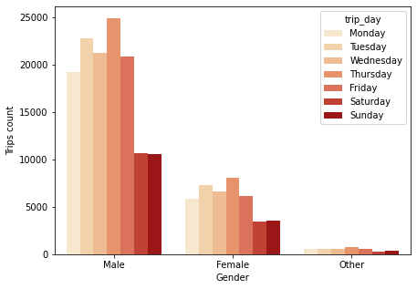

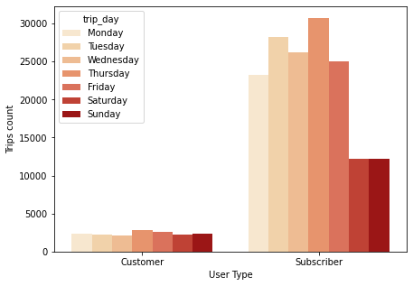

```python
f_mg_td= plt.figure(new_figId(), figsize=(7,5))
sb.countplot(data= df, x= 'member_gender', hue='trip_day', palette= 'OrRd').set(xlabel='Gender', ylabel='Trips count');

f_ut_td= plt.figure(new_figId(), figsize=(7,5))
sb.countplot(data= df, x= 'user_type', hue='trip_day', palette= 'OrRd').set(xlabel='User Type', ylabel='Trips count');


visualize(f_mg_td, f_ut_td)
```

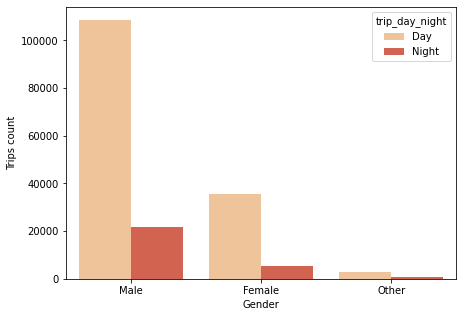

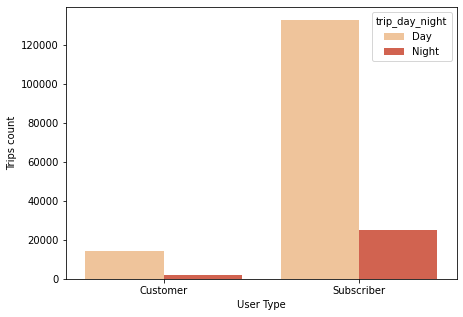

```python
f_mg_tdn= plt.figure(new_figId(), figsize=(7,5))
sb.countplot(data= df, x= 'member_gender', hue='trip_day_night', palette= 'OrRd').set(xlabel='Gender', ylabel='Trips count');

f_ut_tdn= plt.figure(new_figId(), figsize=(7,5))
sb.countplot(data= df, x= 'user_type', hue='trip_day_night', palette= 'OrRd').set(xlabel='User Type', ylabel='Trips count');

visualize(f_mg_tdn, f_ut_tdn)
```

In general, The above bar charts are supporting the results discovered in the previous analysis. The trip start time in week ends is almost the opposite of the week days